# final_project

## Section 0: Introduction & Goals

This report will explore the complex relationship of factors related to the chosen y-variable `Poor.Health` (the poor health index).

### Investigative Questions

We will explore several key areas:

1. **Quality of Care**: How does a county's level of access to healthcare affect the health index?
2. **Environmental Factors**: How do environmental factors (such as unemployment rate, median household income, or education levels) vary across counties with different health indices? How do these variables correlate with the health index at a county level? How do these environmental variables relate with the quality of care in a county?
3. **Behavioral Factors**: How do behavioral factors (which include obesity rates, smoking, drinking, etc.) correlate with the Health Index at a county level? Is there any socioeconomic relationship between behavioral factors and enviromental factors?
4. **Demographic/Political Factors**: Are there any notable relationships between a county's health index and demographic/political variables? While the primary focus is the health index, is there any observable relationship between the political leaning of a county in the 2016 Election and its Health Index?

### Hypothesis

My initial hypothesis is that socioeconomic environmental factors, particularly median household income, will have the strongest correlation with the health index. The median household income will likely influence certain behavioral and demographic variables (like smoking, drinking, sufficient sleeping rates) that are closely linked with certain health outcomes; in this way, median household income will act as a confounding factor on other variables that affect the poor health index.

### Objective

Our primary objective is to identify which of these contexts—quality of care, environmental, behavioral, and demographic—exert the most substantial impact on the Poor Health Index, which may be used to provide insights for future targeted health interventions and policy planning.

## Section 1: Data Import and Summary

```python
import pandas as pd
import seaborn as sns
import numpy as np
import matplotlib.pyplot as plt

county_df = pd.read_csv("project_4770_7770.csv")
county_df.head()
```

|  | Row.Label | Five-digit.FIPS.Code | State.FIPS.Code | County.FIPS.Code | State.Abbreviation | CountyName | Poor.Health | Election.Results.2016 | Uninsured | Primary.Care.Physicians.Per.1000 | ... | Median.Household.Income | Severe.Housing.Problems | Unemployment | Food.Insecurity.Quintile | Income.Inequality.Quartile | Percent.Rural | Over.65 | Percent.Females | Life.Expectancy | Population |
| --- | --- | --- | --- | --- | --- | --- | --- | --- | --- | --- | --- | --- | --- | --- | --- | --- | --- | --- | --- | --- | --- |
| 0 | AL_Autauga County | 1001 | 1 | 1 | AL | Autauga County | 0.1841 | Republican | 0.0850 | 0.415 | ... | 58343 | 0.1495 | 0.0386 | Q3 | Q3 | 0.4200 | 0.151 | 0.513 | 76.330589 | 55504 |
| 1 | AL_Baldwin County | 1003 | 1 | 3 | AL | Baldwin County | 0.1806 | Republican | 0.1070 | 0.729 | ... | 56607 | 0.1383 | 0.0399 | Q3 | Q3 | 0.4228 | 0.199 | 0.515 | 78.599498 | 212628 |
| 2 | AL_Barbour County | 1005 | 1 | 5 | AL | Barbour County | 0.2577 | Republican | 0.1251 | 0.385 | ... | 32490 | 0.1546 | 0.0590 | Q5 | Q4 | 0.6779 | 0.188 | 0.472 | 75.779457 | 25270 |
| 3 | AL_Bibb County | 1007 | 1 | 7 | AL | Bibb County | 0.2000 | Republican | 0.0968 | 0.574 | ... | 45795 | 0.1096 | 0.0439 | Q4 | Q2 | 0.6835 | 0.160 | 0.465 | 73.928271 | 22668 |
| 4 | AL_Blount County | 1009 | 1 | 9 | AL | Blount County | 0.2110 | Republican | 0.1211 | 0.225 | ... | 48253 | 0.1040 | 0.0402 | Q2 | Q2 | 0.8995 | 0.178 | 0.507 | 74.597767 | 58013 |

5 rows × 27 columns

In order to get a more comprehensive idea of our chosen y-variable and our dataset, let's take a look at some of the descriptive statistics for the `Poor.Health` index.

The dataset consists of 2715 samples (i.e. 2715 counties), and the `Poor.Health` index is centered at around 0.16. The distribution of the health index is appears to be unimodal and positively skewed, with several noticeable outliers beyond a value of 0.30 on the health index.

```python
# general descriptive statistics of the health index
desc_stats = county_df['Poor.Health'].describe()
print("===== Descriptive Statistics of Poor Health Index =====")
print(desc_stats)

# quartile analysis
quartiles = county_df['Poor.Health'].quantile([0.25, 0.5, 0.75])
print("\n===== Quartile Analysis of Poor Health Index =====")
print(quartiles)
```

```
===== Descriptive Statistics of Poor Health Index =====
count    2715.000000
mean        0.174385
std         0.045176
min         0.082900
25%         0.140350
50%         0.167300
75%         0.203950
max         0.407300
Name: Poor.Health, dtype: float64

===== Quartile Analysis of Poor Health Index =====
0.25    0.14035
0.50    0.16730
0.75    0.20395
Name: Poor.Health, dtype: float64
```

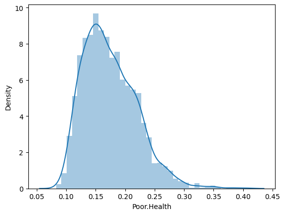

```python
import warnings
warnings.filterwarnings('ignore')
# view the distribution of the health index
sns.distplot(county_df['Poor.Health']);
```

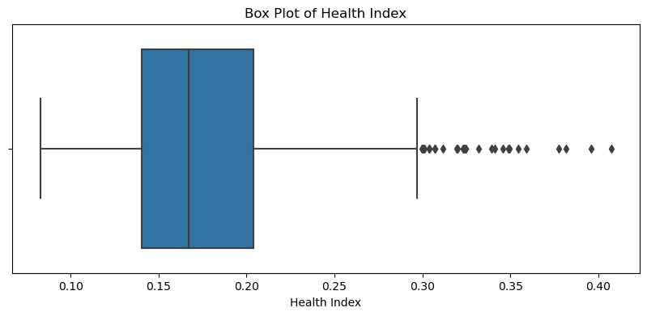

```python
# box plot visualization
plt.figure(figsize=(10, 4))
sns.boxplot(county_df['Poor.Health'])
plt.title('Box Plot of Health Index')
plt.xlabel('Health Index')
plt.show()
```

Let's use a correlation matrix to get a preliminary visualization of the correlations between our dataset x-variables. This will help us determine which variables we may want to consider in our exploration of the dataset. We will look for variables with strong correlations (near 1 or -1, i.e. the very light or very darkly colored squared) in the heatmap.

Some variables with strong correlations that we may want to analyze include

- Quality of Care: `Uninsured`, `Primary.Care.Physicians.Per.1000`
- Environmental: `Median.Household.Income`
- Behavioral: `Excessive.Drinking`, `Physical.Inactivity`, `Insufficient.Sleep`, `Proportion.of.Smokers`, `Adult.Obesity`
- Demographic/Political: `Life.Expectancy`

This initial analysis of the dataset suggests that behavioral determinants of health appear to have the most effect on the poor health index of a county. It is also important to note that these correlations do not necessarily indicate causation; some of these variables like `Life.Expectancy` are inherently linked to the health index evaluation of a county, as a lower poor health index (i.e. better health outcomes) would suggest a higher life expectancy in a county.

This appears to support my initial hypothesis that `Median.Household.Income` will have a strong correlation with the poor health index and the other independent variables in the dataset.

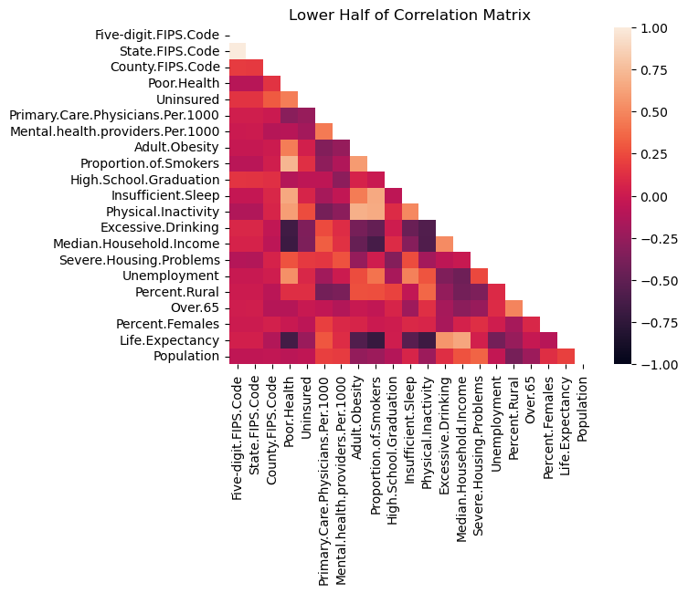

```python
# Calculate the correlation matrix
correlation_matrix = county_df.corr()

# Create a mask to display only the lower triangle of the matrix
mask = np.triu(np.ones_like(correlation_matrix, dtype=bool))

# Create a heatmap with the mask
sns.heatmap(correlation_matrix, mask=mask, annot=False, vmin=-1, vmax=1, cmap='rocket', center=0)
plt.title('Lower Half of Correlation Matrix')
plt.show()
```

Since our analysis will focus primarily on the `Health.Index,Quintile` and `Median.Income.Quintile` variables, let's quantize these two variables for easier analysis later on.

We will create two new columns that describe the health index and median income in terms of quintiles. The `0-20%` bracket represents the highest 20% of values and the `80-100%` bracket represents the smallest 20% of values in the distribution. For example, the 0-20% category of `Poor.Health` represents the top 20% poor health index values (i.e. counties with worst health) and the 80-100% category represents the bottom 20% smallest health index values (i.e. counties with best health). Similarly, the 0-20% category of `Median.Household.Income` represents the bottom 20% of the income distribution (lowest income counties) and the 80-100% category represents the top 20% (highest income counties).

```python
# quantizing data into 5 bins. 1 = lowest value, 5 = highest value (poor health index)
county_df_quantiles = county_df.copy()
# the labels correspond to the quantiles from lowest to highest by default.
county_df_quantiles['Health.Index.Quintile'] = pd.qcut(county_df_quantiles['Poor.Health'], q=5, labels=['80-100%', '60-80%', '40-60%', '20-40%', '0-20%'])
county_df_quantiles['Median.Income.Quintile'] = pd.qcut(county_df_quantiles['Median.Household.Income'], q=5, labels=['80-100%', '60-80%', '40-60%', '20-40%', '0-20%'])
county_df_quantiles.head()
```

|  | Row.Label | Five-digit.FIPS.Code | State.FIPS.Code | County.FIPS.Code | State.Abbreviation | CountyName | Poor.Health | Election.Results.2016 | Uninsured | Primary.Care.Physicians.Per.1000 | ... | Unemployment | Food.Insecurity.Quintile | Income.Inequality.Quartile | Percent.Rural | Over.65 | Percent.Females | Life.Expectancy | Population | Health.Index.Quintile | Median.Income.Quintile |
| --- | --- | --- | --- | --- | --- | --- | --- | --- | --- | --- | --- | --- | --- | --- | --- | --- | --- | --- | --- | --- | --- |
| 0 | AL_Autauga County | 1001 | 1 | 1 | AL | Autauga County | 0.1841 | Republican | 0.0850 | 0.415 | ... | 0.0386 | Q3 | Q3 | 0.4200 | 0.151 | 0.513 | 76.330589 | 55504 | 20-40% | 20-40% |
| 1 | AL_Baldwin County | 1003 | 1 | 3 | AL | Baldwin County | 0.1806 | Republican | 0.1070 | 0.729 | ... | 0.0399 | Q3 | Q3 | 0.4228 | 0.199 | 0.515 | 78.599498 | 212628 | 40-60% | 20-40% |
| 2 | AL_Barbour County | 1005 | 1 | 5 | AL | Barbour County | 0.2577 | Republican | 0.1251 | 0.385 | ... | 0.0590 | Q5 | Q4 | 0.6779 | 0.188 | 0.472 | 75.779457 | 25270 | 0-20% | 80-100% |
| 3 | AL_Bibb County | 1007 | 1 | 7 | AL | Bibb County | 0.2000 | Republican | 0.0968 | 0.574 | ... | 0.0439 | Q4 | Q2 | 0.6835 | 0.160 | 0.465 | 73.928271 | 22668 | 20-40% | 60-80% |
| 4 | AL_Blount County | 1009 | 1 | 9 | AL | Blount County | 0.2110 | Republican | 0.1211 | 0.225 | ... | 0.0402 | Q2 | Q2 | 0.8995 | 0.178 | 0.507 | 74.597767 | 58013 | 20-40% | 40-60% |

5 rows × 29 columns

## Section 2: Exploratory Data Analysis

### 2.1 Quality of Care

In this section, we will explore the relationship between a county's access to health care and the poor health index.

First, let's visualize the relationship between the poor health index and each of the predictor variables related to health care access.

The variable containing the most distribution stratification is the `uninsurance rate`. As a county's poor health index decreases (i.e. the county's health outcomes improve), the median uninsured rate of the county population noticeably decreases. Additionally, the variance in the uninsurance rate tends to decrease as the poor health index decreases as well.

There surprisingly does not exist a significantly noticeable difference in the unimodal peaks of the mental health or primary care physician rate, but the physician rate distributions are more positively skewed in "healthier" counties.

**When analyzing the graphs, remember that 80-100% represents the lowest 20% of the poor health index (best health) and 0-20% is the top 20% of poor health index (worst health). 80-100% of median income is lowest 20% income bracket (poorer), and 0-20% is the highest 20% income bracket (richer).**

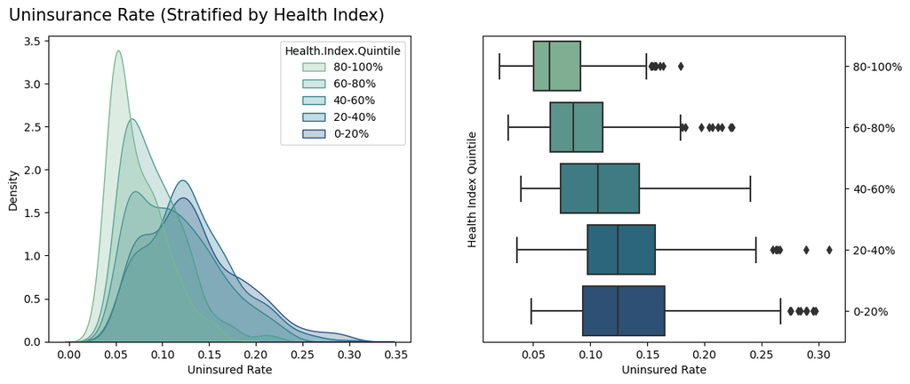

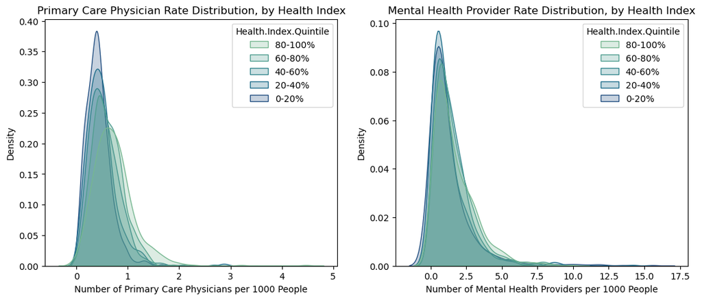

```python
plt.figure(figsize=(20, 5))

# Plot 1: Uninsurance rate distribution
ax1 = plt.subplot(1, 3, 1)
sns.kdeplot(data=county_df_quantiles, x='Uninsured', hue='Health.Index.Quintile', fill=True, palette='crest')
ax1.set_ylabel('Density', rotation=90)  # Rotate y-axis label
ax1.set_xlabel('Uninsured Rate')

# Plot 2: Uninsurance rate box plot

ax2 = plt.subplot(1, 3, 2)
sns.boxplot(data=county_df_quantiles, x='Uninsured', y='Health.Index.Quintile', palette='crest', showfliers=True)
ax2.set_xlabel('Uninsured Rate')
ax2.set_ylabel('Health Index Quintile')
ax2.yaxis.tick_right()  # Move y-axis ticks and labels to the right side
plt.suptitle("Uninsurance Rate (Stratified by Health Index)", x=0.1, y=.95, horizontalalignment='left', verticalalignment='top', fontsize = 15)
plt.show()

plt.figure(figsize=(20, 5))
# plot 3: primary care physician rate distribution
plt.subplot(1, 3, 1)
sns.kdeplot(data=county_df_quantiles, x='Primary.Care.Physicians.Per.1000', hue='Health.Index.Quintile', fill=True, palette='crest')
plt.xlabel('Number of Primary Care Physicians per 1000 People')
plt.ylabel('Density')
plt.title('Primary Care Physician Rate Distribution, by Health Index')
# plot 4: mental health provider rate distribution
plt.subplot(1, 3, 2)
sns.kdeplot(data=county_df_quantiles, x='Mental.health.providers.Per.1000', hue='Health.Index.Quintile', fill=True, palette='crest')
plt.xlabel('Number of Mental Health Providers per 1000 People')
plt.ylabel('Density')
plt.title('Mental Health Provider Rate Distribution, by Health Index')
plt.show()
```

Since the uninsurance rate seems to have the largest correlation with the poor health index, the relationship between these two variables is visualized below. There is a visible positive correlation between the two.

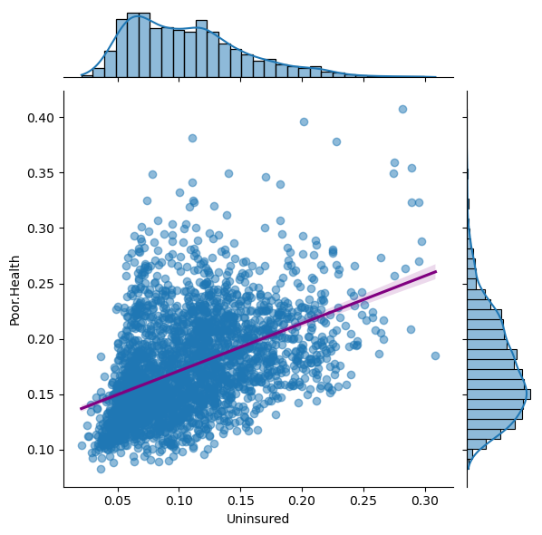

```python
# sns.regplot(data=county_df_quantiles, x='Uninsured', y='Poor.Health', scatter_kws={'alpha':0.5}, line_kws={'color':'purple'})
sns.jointplot(data=county_df, x='Uninsured', y='Poor.Health', kind='reg', scatter_kws={'alpha':0.5}, line_kws={'color':'purple'})
plt.ylabel('Health Index')
plt.xlabel('Uninsured Rate')
plt.show()
```

Overall, a decreased access to healthcare (specifically in the form of uninsurance, which importantly is a factor that is highly linked to employment and economic status) appears to correlate with poorer health outcomes/higher poor health index.

### 2.2 Environmental Social Determinants of Health

In this section, we will explore the relationship between environmental social deterinants of health with the county-level health index. My hypothesis focuses on the importance of the `Median.Household.Income` as a proxy for the socioeconomic status of a county; the correlation matrix from section 1 and the analysis of uninsurance in section 2.1 also suggest that `Median.Household.Income` will be an important predictor of the poor health index.

**Remember 80-100% is lowest health index best health, 0-20% is worst health. 80-100% of income is lowest income, 0-20% is best health.**

Let's look at `Median.Household.Income` and `Unemployment` as representative views of a county's economic status.

Interestingly, the unemployment rate of the middle quintiles health index counties are all pretty similar; the top quintil sees a very large shift to the left with a significantly lower average unemployment rate, and the bottom quintile is noticeably more variant than the others. This suggests that the middle health index quintiles are distinguished by some other factors, while the top and bottom can generally be distringuished by their abnormally high/low unemployment rates.

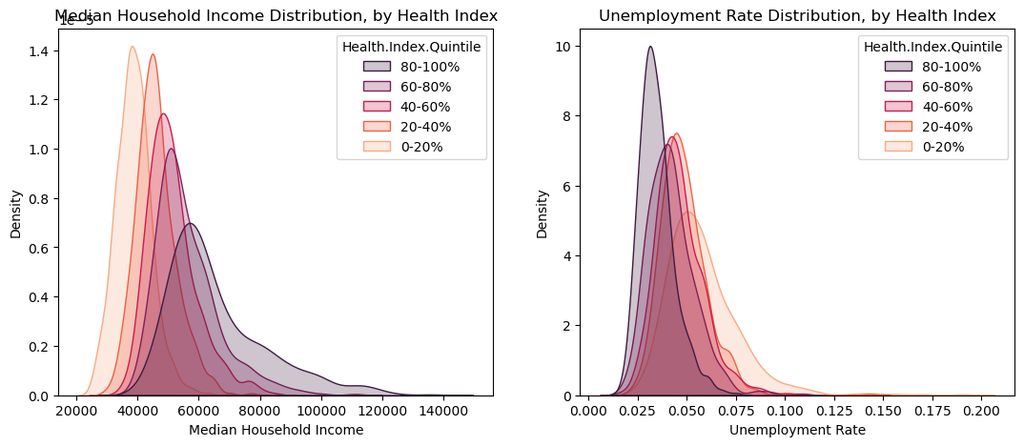

```python
# we see from this cell that median income appears to have a strong correlation with health index
plt.figure(figsize=(20, 5))
# plot 1: median income distribution
plt.subplot(1, 3, 1)
sns.kdeplot(data=county_df_quantiles, x='Median.Household.Income', hue='Health.Index.Quintile', fill=True, palette='rocket')
# sns.histplot(data=county_df_quantiles, x='Median.Household.Income', hue='Health.Index.Quintile', multiple='stack', palette='hls', kde=True)
plt.xlabel('Median Household Income')
plt.ylabel('Density')
plt.title('Median Household Income Distribution, by Health Index')

# plot 2: unemployment rate distribution
plt.subplot(1, 3, 2)
sns.kdeplot(data=county_df_quantiles, x='Unemployment', hue='Health.Index.Quintile', fill=True, palette='rocket')
# sns.histplot(data=county_df_quantiles, x='Unemployment', hue='Health.Index.Quintile', multiple='stack', palette='hls', kde=True)
plt.xlabel('Unemployment Rate')
plt.ylabel('Density')
plt.title('Unemployment Rate Distribution, by Health Index')
plt.show()
```

To further explore my earlier hypothesis involving `Median.Household.Income`, let's plot the distribution of the health index by a county's median income using boxen plots. As hypothesized, the poor health index tends to decrease as the median household income increases (i.e. approach the top 20%, or the 0-20% income quantile). There is a clear decrease in the median health index score as household income increases.

Additionally, we see that the skew of the positive tail of the overall health index distribution consists almost entirely with samples from the lowest income quantile. The variance of health index distribution also decreases as income increases.

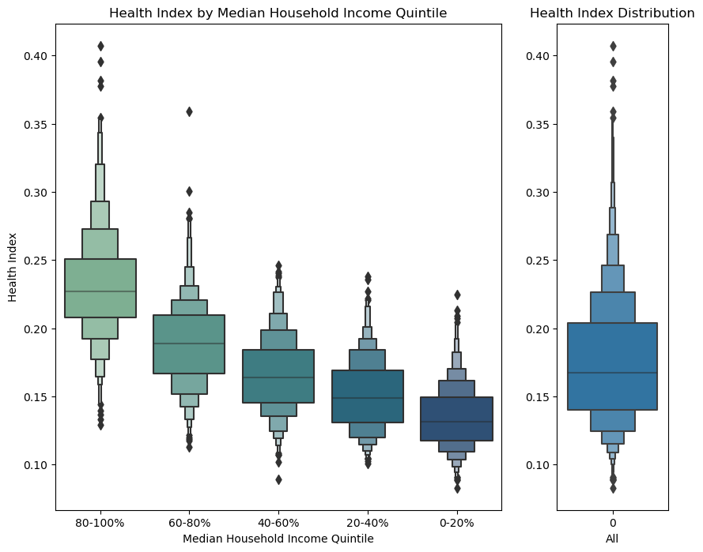

```python
fig = plt.figure(figsize=(10, 8))
gs = fig.add_gridspec(1, 2, width_ratios=[8, 2])
ax0 = fig.add_subplot(gs[0, 0])
ax1 = fig.add_subplot(gs[0, 1], sharey=ax0)
ax1.set_ylabel('')
# sns.boxplot(data=county_df_quantiles, x='Median.Income.Quintile', y='Poor.Health', palette='crest', showfliers=True, ax=ax0)
sns.boxenplot(data=county_df_quantiles, x='Median.Income.Quintile', y='Poor.Health', palette='crest', showfliers=True, ax=ax0)

ax0.set_xlabel('Median Household Income Quintile')
ax0.set_ylabel('Health Index')
ax0.set_title('Health Index by Median Household Income Quintile')
# sns.boxplot(data=county_df_quantiles['Poor.Health'], showfliers=True, ax=ax1)
sns.boxenplot(data=county_df_quantiles['Poor.Health'], showfliers=True, ax=ax1)
ax1.set_xlabel('All')
ax1.set_title('Health Index Distribution')
plt.show()
```

Let's visualize the correlation between the `Median.Household.Income` with some of our other important variables (namely `Poor.Health` and `Uninsured`). There is a clear negative correlation between median household income and the poor health index; there is a similar negative correlation between median household income and the uninsurance rate. This further cements the idea of a socioeconomic factor (like median income and the likely employment-based uninsurace rate) contributing to a county's poor health index that was first suggested in Section 2.1.

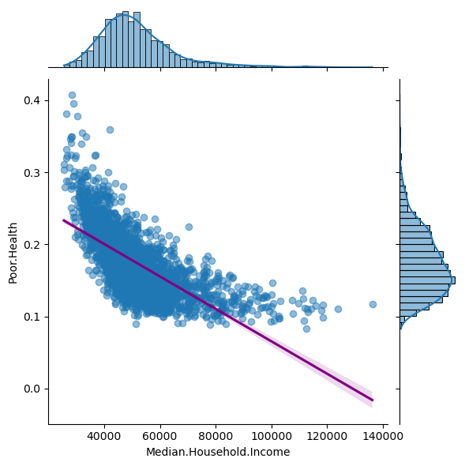

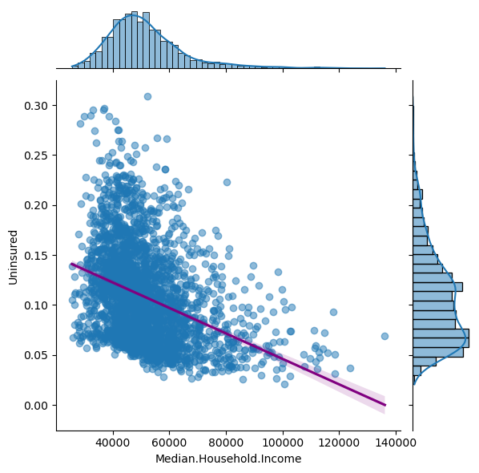

```python
# plot 2: median household income vs health index
sns.jointplot(data=county_df, x='Median.Household.Income', y='Poor.Health', kind='reg', scatter_kws={'alpha':0.5}, line_kws={'color':'purple'})
# relationshiph between income and uninsurance - we see that there is a strong negative correlation between the two
sns.jointplot(data=county_df, x='Median.Household.Income', y='Uninsured', kind='reg', scatter_kws={'alpha':0.5}, line_kws={'color':'purple'})
```

We've seen how increased median household income leads to better health outcomes and lower uninsurance rates. To further explore how the relationship between median household income and uninsurance rates affects the poor health index, the graph below shows the relationship between uninsurance and the health index when accounting for the median income quintile.

Within the general trend of increasing uninsurance leaading to poorer health, we see that as uninsurance increases the poor health index tends to increase within each of the income quintiles. Additionally, each of the stratified trend lines appear to have a shallower slope than the overall general trend line (suggesting that income differences account for some of the variation that we attributed to uninsurance). The trend line of the bottom quintile (80-100%) is relatively flat despite changes in the uninsurance rate, suggesting that median income might have "more" of an effect than uninsurance on the health index for low-income counties.

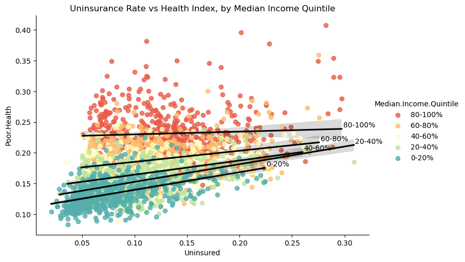

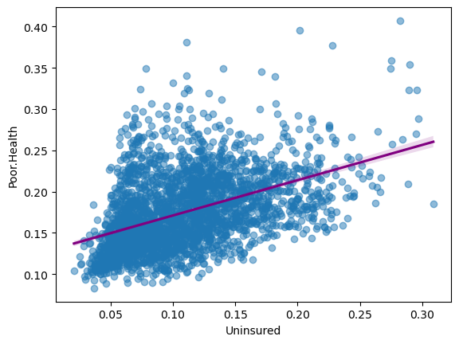

```python
# uninsurance rate vs health index (we use uninsurance rate because it appears to be the most correlated with health index)
# additionally, we can color by median income quintile since that is likely related to the uninsurance rate
g = sns.lmplot(data=county_df_quantiles, x='Uninsured', y='Poor.Health', hue='Median.Income.Quintile', palette='Spectral', height=5, aspect=1.5, scatter_kws={'alpha':0.8}, line_kws={'color':'black'})
fig = g.fig
ax = g.ax
for line, label in zip(ax.get_lines(), county_df_quantiles['Median.Income.Quintile'].unique().sort_values()):
    x = line.get_xdata()[-1]
    y = line.get_ydata()[-1]
    ax.annotate(label, xy=(x, y), xytext=(2,2), textcoords="offset points", color=line.get_color())
plt.title('Uninsurance Rate vs Health Index, by Median Income Quintile')
plt.show()

# general uninsured rate vs health index
sns.regplot(data=county_df_quantiles, x='Uninsured', y='Poor.Health', scatter_kws={'alpha':0.5}, line_kws={'color':'purple'})
```

In order to truly analyze the effects of median household income and health care access (in the form of uninsurance) on health outcomes, we will perform a regression analysis on `Poor.Health`, `Median.Household.Income`, `Uninsured`, and the interaction betwen `Median.Household.Income` and `Uninsured`.

The outputs of the OLS regression test has:

- **R-squared** (0.531): this suggests that approximately 53.1% of the variability in `Poor.Health` can be explained by the model.
- **Coefficients**
  - `Q('Median.Household.Income')` (-1.034e-06): suggests a small negative association between `Median.Household.Income` and `Poor.Health`.
  - `Uninsured` (0.7479): suggests a positive association between the county-level uninsurance rate and `Poor.Health`.
  - `Q('Median.Household.Income'):Uninsured` (-1.083e-05): the interaction term suggests a negative relationship between median household income and the uninsurance rate. This aligns with previous analysis, where increasing income saw a decrease in uninsurance.
- **p-values**: All the predictors have small p-values (less than 0.05), indicating that the predictors are statistically significant

Overall, this OLS test suggests that the uninsured rate has the largest practical influence on the poor health index, indicating that the effect of median household income on the uninsurance rate is what allows it to influence the poor health index.

```python
# REGRESSION ANALYSIS: model for poor.health and median.household.income
import statsmodels.formula.api as smf
import math

model = smf.ols(formula="Q('Poor.Health') ~ Q('Median.Household.Income') + Uninsured + Q('Median.Household.Income'):Uninsured", data=county_df_quantiles).fit()
print(model.summary())
```

```
                            OLS Regression Results
==============================================================================
Dep. Variable:       Q('Poor.Health')   R-squared:                       0.531
Model:                            OLS   Adj. R-squared:                  0.531
Method:                 Least Squares   F-statistic:                     1024.
Date:                Thu, 21 Dec 2023   Prob (F-statistic):               0.00
Time:                        15:35:18   Log-Likelihood:                 5585.4
No. Observations:                2715   AIC:                        -1.116e+04
Df Residuals:                    2711   BIC:                        -1.114e+04
Df Model:                           3
Covariance Type:            nonrobust
==========================================================================================================
                                             coef    std err          t      P>|t|      [0.025      0.975]
----------------------------------------------------------------------------------------------------------
Intercept                                  0.2048      0.005     37.390      0.000       0.194       0.216
Q('Median.Household.Income')           -1.034e-06   9.89e-08    -10.454      0.000   -1.23e-06    -8.4e-07
Uninsured                                  0.7479      0.051     14.717      0.000       0.648       0.848
Q('Median.Household.Income'):Uninsured -1.083e-05   1.01e-06    -10.679      0.000   -1.28e-05   -8.84e-06
==============================================================================
Omnibus:                      177.956   Durbin-Watson:                   1.124
Prob(Omnibus):                  0.000   Jarque-Bera (JB):              230.725
Skew:                           0.598   Prob(JB):                     7.92e-51
Kurtosis:                       3.781   Cond. No.                     4.61e+06
==============================================================================

Notes:
[1] Standard Errors assume that the covariance matrix of the errors is correctly specified.
[2] The condition number is large, 4.61e+06. This might indicate that there are
strong multicollinearity or other numerical problems.
```

### 2.3 Behavioral Social Determinants of Health

This section will explore behavioral social determinants of health and how they correlate with the health index. Behavioral factors include obesity rates, smoking, excess drinking, and insufficient sleeping, all of which are generally acknowledged contributers to poor health. The correlation matrix from section 1 suggests that `Excessive.Drinking` and `Physical.Inactivity` may have the largest correlations with the health index and the other predictor variables.

Remember 80-100% is lowest health index best health, 0-20% is worst health. 80-100% of income is lowest income, 0-20% is best health.

Since each of the behavioral variables in this category are widely associated with poor health outcomes, I decided to quickly analyze the general trends between each of these behavioral variables with the `Poor.Health` index and `Median.Household.Income` (as these are two variables that were deemed significant for socioeconomic representation in previous sections).

Most of the trends are as expected: higher rates of county-level obesity, smoking, insufficient sleep, and physical inactivity are generally seen with a higher poor health index. Additionally, an increase in these variables are associated with a decrease in median household income; this is understandable as a decrease in median household income is also associated with an increase in the poor health index.

The most surprisingly trend is in the `Excessive.Drinking` cateogry; an increase in excessive drinking was associated with an increased median household income and a decreased poor health index. This suggests that folks with higher and more disposable income are more likely to participate in excessive drinking; however, their higher median income will also explain the decrease in their poor health index. There is also an interesting noticeable outlier of counties with a low amount of Excessive Drinking (~0.10) and a small poor health index (~0.1).

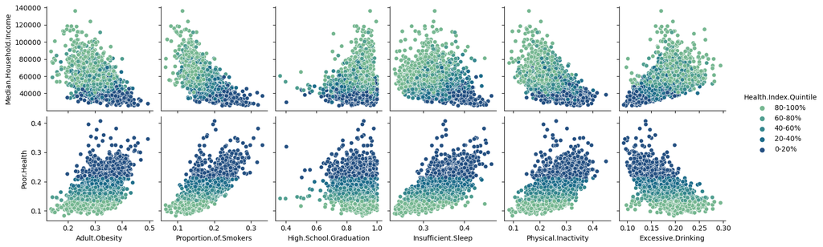

```python
sns.pairplot(data=county_df_quantiles, x_vars=['Adult.Obesity', 'Proportion.of.Smokers', 'High.School.Graduation',
       'Insufficient.Sleep', 'Physical.Inactivity', 'Excessive.Drinking'], y_vars=['Median.Household.Income', 'Poor.Health'], hue='Health.Index.Quintile', palette='crest', height=2.5)
plt.show()
```

To further explore this surprising association, the plots of the excessive drinking and smoking proportions of the population when accounting for county health index and median income are shown below.

The relationship between smoking, income, and health index is as expected: unhealthy counties with higher health indices had higher proportions of smokers and a lower median income. Excessive drinking had an opposing trend: healthier counties with lower poor health indices had higher proportions of excessive drinking and a generally high median income quintile. The explanation of a high median income potentially acting as a confounding factor between good health outcomes and excessive drinking may be at play.

**When analyzing the graphs, remember that 80-100% represents the lowest 20% of the poor health index (best health) and 0-20% is the top 20% of poor health index (worst health). 80-100% of median income is lowest 20% income bracket (poorer), and 0-20% is the highest 20% income bracket (richer).**

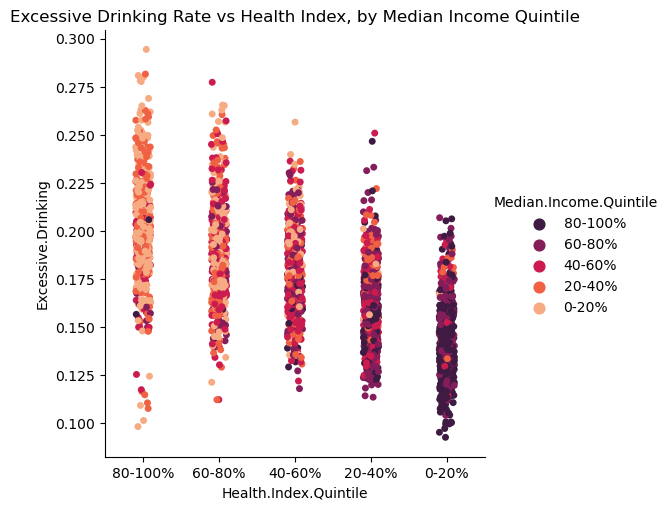

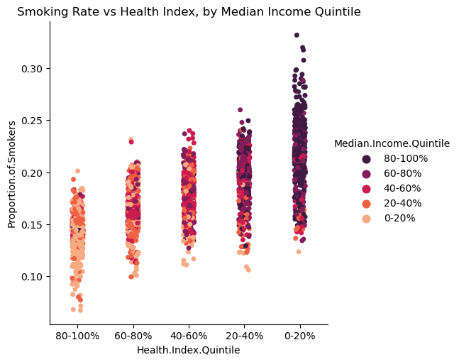

```python
sns.catplot(data=county_df_quantiles, x='Health.Index.Quintile', y='Excessive.Drinking', hue='Median.Income.Quintile', palette='rocket')
plt.title('Excessive Drinking Rate vs Health Index, by Median Income Quintile')
plt.show()
sns.catplot(data=county_df_quantiles, x='Health.Index.Quintile', y='Proportion.of.Smokers', hue='Median.Income.Quintile', palette='rocket')
plt.title('Smoking Rate vs Health Index, by Median Income Quintile')
plt.show()
```

Additionally, the overall distribution of `Excessive.Drinking` has a higher variance in higher income quintiles. The median amount of excessive drinking has a clear positive correlation with median income.

**When analyzing the graphs, remember that 80-100% represents the lowest 20% of the poor health index (best health) and 0-20% is the top 20% of poor health index (worst health). 80-100% of median income is lowest 20% income bracket (poorer), and 0-20% is the highest 20% income bracket (richer).**

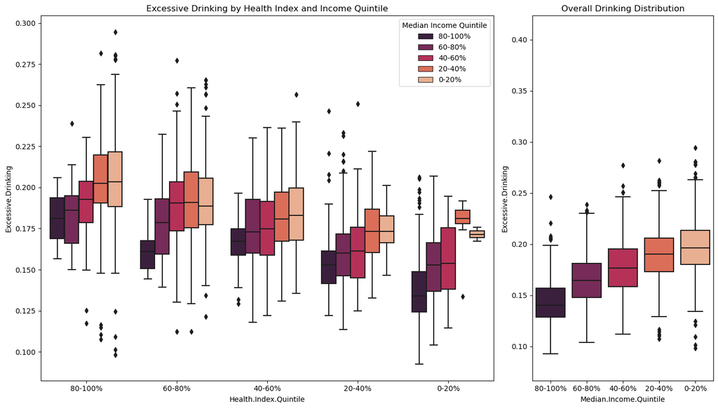

```python
fig = plt.figure(figsize=(14, 8))
gs = fig.add_gridspec(1, 2, width_ratios=[10, 4])
ax1 = fig.add_subplot(gs[0, 0])
ax2 = fig.add_subplot(gs[0, 1], sharey=ax0)
ax2.set_ylabel('')
# sns.boxplot(data=county_df_quantiles, x='Median.Income.Quintile', y='Poor.Health', palette='crest', showfliers=True, ax=ax0)
sns.boxplot(data=county_df_quantiles, x='Health.Index.Quintile', y='Excessive.Drinking', hue='Median.Income.Quintile', palette='rocket', ax=ax1)
ax1.set_title('Excessive Drinking by Health Index and Income Quintile')
ax1.legend(loc='upper right', title='Median Income Quintile')

sns.boxplot(data=county_df_quantiles, x='Median.Income.Quintile', y='Excessive.Drinking', palette='rocket', ax=ax2)
ax2.set_title('Overall Drinking Distribution')

plt.tight_layout()
plt.show()
```

### 2.4 Demographic/Political Determinants of Health

This section will explore any notable relationships involving a county's demographic/political characteristics as determinants of health.

**When analyzing the graphs, remember that 80-100% represents the lowest 20% of the poor health index (best health) and 0-20% is the top 20% of poor health index (worst health). 80-100% of median income is lowest 20% income bracket (poorer), and 0-20% is the highest 20% income bracket (richer).**

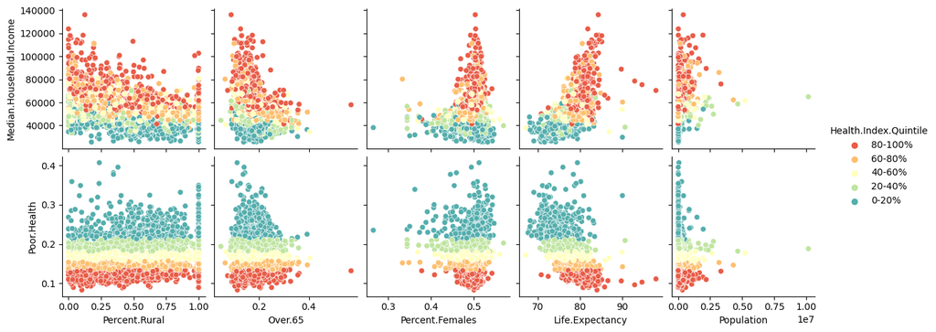

```python
sns.pairplot(data=county_df_quantiles, x_vars=['Percent.Rural', 'Over.65', 'Percent.Females', 'Life.Expectancy',
       'Population'], y_vars=['Median.Household.Income', 'Poor.Health'], hue='Health.Index.Quintile', palette='Spectral', height=2.5)
```

To evaluate a relationship between the political orientation of a county and its health index, let's look at the following mosaic plot and histogram. The mosaic plot shows the proportion of republicans and democrats within each of the health index quintiles; there appears to be a higher concentration of democratic counties within the top and bottom health quintiles. However, the mosaic plot isn't that useful overall because of quantity differences in the number of democratic and republican counties.

From the histogram, we notice that both political parties follow a similar right-skewed distribution in the health index; the Republican distribution has a unimodal peak at a higher poor health index than the Democratic distribution, and the Democratic distribution ha a more significant positive skew than the Republicans.

**When analyzing the graphs, remember that 80-100% represents the lowest 20% of the poor health index (best health) and 0-20% is the top 20% of poor health index (worst health). 80-100% of median income is lowest 20% income bracket (poorer), and 0-20% is the highest 20% income bracket (richer).**

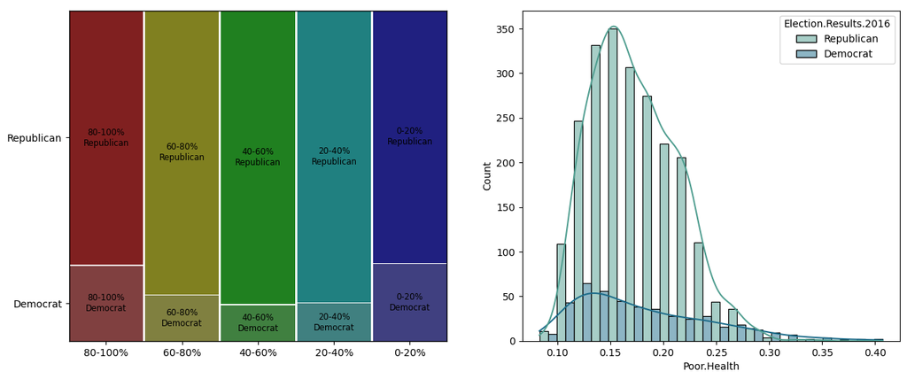

```python
from statsmodels.graphics.mosaicplot import mosaic

fig, axes = plt.subplots(1, 2, figsize=(15, 6))

mosaic_data = county_df_quantiles.groupby(['Health.Index.Quintile', 'Election.Results.2016']).size()
mosaic(mosaic_data, ax=axes[0])

sns.histplot(data=county_df_quantiles, x='Poor.Health', hue='Election.Results.2016', palette='crest', multiple='dodge', kde=True, bins=20, ax=axes[1])
# sns.lineplot(data=county_df_quantiles, x='Poor.Health', hue='Election.Results.2016', palette='crest', ax=axes[1])
plt.show()
```

As median household income was shown to be strongly correlated with the health index in previous sections and is thought to play a significant role in the political leanings of an individual, let's analyze the poor health distribution of each party when stratified by income.

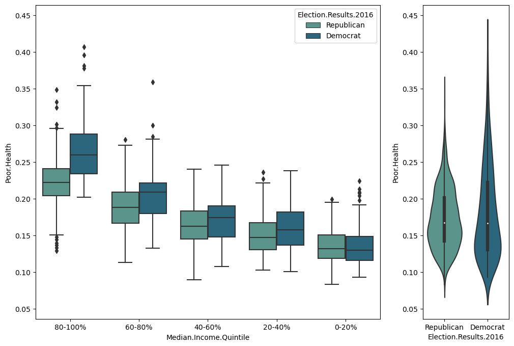

```python
fig = plt.figure(figsize=(12, 8))
gs = fig.add_gridspec(1, 2, width_ratios=[8, 2])
ax0 = fig.add_subplot(gs[0, 0])
ax1 = fig.add_subplot(gs[0, 1], sharey=ax0)
# plot of median income vs health index by political party, stratified by median income quintile
plt.subplot(1, 2, 1)
sns.boxplot(data=county_df_quantiles, x='Median.Income.Quintile', y='Poor.Health', hue='Election.Results.2016', palette='crest')

# plot of health index by political party, overall
plt.subplot(1, 2, 2)
sns.violinplot(data=county_df_quantiles, x='Election.Results.2016', y='Poor.Health', palette='crest')
```

Overall, there does seem to be some sort of mild relationship between a county's political leaning and its health index, but this relationship can likely be attributed to some sort of socioeconomic factor like income that affects both politics and health.

## Section 3: Predictive Model

This section will train a decision tree to predict a county's health index. We will then analyze the decision tree to see which factors are most important in determining the health index.

First, we will preprocess our data by binarizing the continuous variables and splitting our dataset into train/test sets.

```python
# section 1: create a df to fit the tree on, binarize the continuous variables, split training variables
X_conts = county_df[['Uninsured',
       'Primary.Care.Physicians.Per.1000', 'Mental.health.providers.Per.1000',
       'Adult.Obesity', 'Proportion.of.Smokers', 'High.School.Graduation',
       'Insufficient.Sleep', 'Physical.Inactivity', 'Excessive.Drinking',
       'Median.Household.Income', 'Severe.Housing.Problems', 'Unemployment',
       'Percent.Rural', 'Over.65', 'Percent.Females', 'Life.Expectancy',
       'Population']]
X_cats = county_df[['Election.Results.2016', 'Food.Insecurity.Quintile', 'Income.Inequality.Quartile']]
X_cats_bin = pd.get_dummies(X_cats)
X = pd.concat([X_conts, X_cats_bin], axis=1)
print(X.shape)
X.head(5)
```

```
(2715, 28)
```

|  | Uninsured | Primary.Care.Physicians.Per.1000 | Mental.health.providers.Per.1000 | Adult.Obesity | Proportion.of.Smokers | High.School.Graduation | Insufficient.Sleep | Physical.Inactivity | Excessive.Drinking | Median.Household.Income | ... | Election.Results.2016_Republican | Food.Insecurity.Quintile_Q1 | Food.Insecurity.Quintile_Q2 | Food.Insecurity.Quintile_Q3 | Food.Insecurity.Quintile_Q4 | Food.Insecurity.Quintile_Q5 | Income.Inequality.Quartile_Q1 | Income.Inequality.Quartile_Q2 | Income.Inequality.Quartile_Q3 | Income.Inequality.Quartile_Q4 |
| --- | --- | --- | --- | --- | --- | --- | --- | --- | --- | --- | --- | --- | --- | --- | --- | --- | --- | --- | --- | --- | --- |
| 0 | 0.0850 | 0.415 | 0.162 | 0.375 | 0.191247 | 0.9000 | 0.3591 | 0.311 | 0.168780 | 58343 | ... | 1 | 0 | 0 | 1 | 0 | 0 | 0 | 0 | 1 | 0 |
| 1 | 0.1070 | 0.729 | 0.912 | 0.310 | 0.167955 | 0.8636 | 0.3331 | 0.238 | 0.167150 | 56607 | ... | 1 | 0 | 0 | 1 | 0 | 0 | 0 | 0 | 1 | 0 |
| 2 | 0.1251 | 0.385 | 0.079 | 0.443 | 0.215394 | 0.8141 | 0.3856 | 0.282 | 0.126987 | 32490 | ... | 1 | 0 | 0 | 0 | 0 | 1 | 0 | 0 | 0 | 1 |
| 3 | 0.0968 | 0.574 | 0.088 | 0.378 | 0.199179 | 0.8376 | 0.3815 | 0.349 | 0.159252 | 45795 | ... | 1 | 0 | 0 | 0 | 1 | 0 | 0 | 1 | 0 | 0 |
| 4 | 0.1211 | 0.225 | 0.103 | 0.344 | 0.196525 | 0.9347 | 0.3595 | 0.285 | 0.153787 | 48253 | ... | 1 | 0 | 1 | 0 | 0 | 0 | 0 | 1 | 0 | 0 |

5 rows × 28 columns

```python
y = county_df['Poor.Health']
y.head(5)
```

```
0    0.1841
1    0.1806
2    0.2577
3    0.2000
4    0.2110
Name: Poor.Health, dtype: float64
```

```python
from sklearn.model_selection import train_test_split
X_train, X_test, y_train, y_test = train_test_split(X, y, test_size=0.25)
print(X_train.shape)
print(X_test.shape)
```

```
(2036, 28)
(679, 28)
```

Now, we will use cost-complexity pruning to obtain a decision tree with an optimal score on the test dataset. The best alpha parameter (which is used to balance the depth/complexity of the tree to prevent overfitting on the training data) is `3.5168960230991124e-06` with a test score of `75.21697%`. However, this tree has a depth of `8` which is too large to clearly print and visualize in a jupyter notebook or HTML file.

```python
# section 2: fit the tree using cost complexity pruning
from sklearn import tree

reg_tree_model = tree.DecisionTreeRegressor()
path = reg_tree_model.cost_complexity_pruning_path(X_train, y_train)
ccp_alphas, impurities = path.ccp_alphas, path.impurities

rgrs = []
for ccp_alpha in ccp_alphas:
    rgr = tree.DecisionTreeRegressor(random_state=0, ccp_alpha=ccp_alpha)
    rgr.fit(X_train, y_train)
    rgrs.append(rgr)

train_scores = [rgr.score(X_train, y_train) for rgr in rgrs]
test_scores = [rgr.score(X_test, y_test) for rgr in rgrs]

best_alpha = ccp_alphas[np.argmax(test_scores)]
print("Best alpha: ", best_alpha)
print("Best test score: ", np.max(test_scores))
```

```
Best alpha:  3.5168960230991124e-06
Best test score:  0.7521697245759132
```

```python
best_test_idx = pd.Series(test_scores).idxmax()
print("Best Tree: ", best_test_idx)
print("Best Tree Test Score: ", test_scores[best_test_idx])
print("Best Tree Train Score: ", train_scores[best_test_idx])
print("Best Tree Depth: ", rgrs[best_test_idx].get_depth())
```

```
Best Tree:  1935
Best Tree Test Score:  0.7521697245759132
Best Tree Train Score:  0.8514961225027705
Best Tree Depth:  8
```

For a better visualization, we will re-train a tree using the calculated alpha parameter value above and a depth of 3. The retrained-tree has a lower test accuracy of `64.89173%`, but is more interpretable and simplified.

This tree validates my hypothesis that `Median.Household.Income` is a significantly important determinant of the poor health index; median income is used as the separating criteria in the root node and the first node on the left path. Other criteria used by the tree include `Life.Expectancy`, `Over.65`, `Insufficient.Sleep`, `Proportion.of.Smokers` and `Uninsured`.

The tree also supports some of my earlier conclusions. For example:

- high median household income, high life expectancy, and low uninsurance rates are predictive of a low poor health index
- low median household income, with low over-65 populations or high insufficient-sleep populations lead to high poor health indices

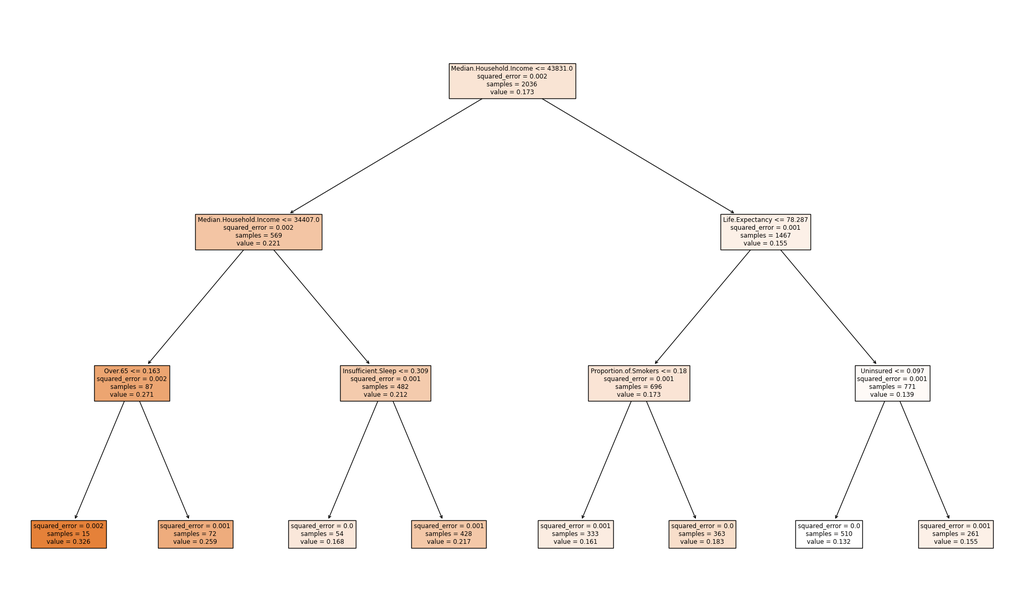

```
Simple Tree Test Score:  0.648917340977458
```

```python
# training a tree with maxdepth for better visualization, since the best tree is too large to visualize
simple_tree = tree.DecisionTreeRegressor(ccp_alpha=best_alpha, max_depth=3)
simple_tree.fit(X_train, y_train)
plt.figure(figsize=(25, 15))
tree.plot_tree(simple_tree, filled=True, feature_names=X.columns)
plt.show()
print("Simple Tree Test Score: ", simple_tree.score(X_test, y_test))
```

## Section 5: Summary

### Recap of Goals and Investigative Questions

Our analysis began with a set of targeted questions centered around four key contexts: Quality of Care, Environmental, Behavioral, and Demographic. These questions related to potential factors influencing the poor health index of a county.

### Key Findings and Conclusions

1. **Quality of Care**: We found that while counties with better health outcomes (lower health index) generally had better access to health care services in the form of a slightly higher primary care and mental health physician presence, the distinguishing variable between counties of different health indices was the uninsured rate.
2. **Environmental Factors**: As hypothesized, counties with higher median incomes had lower poor health indices. There is also a storng tie between health insurance with employment/income: counties with higher median incomes generally saw lower uninsured ratios and lower poor health indices. An OLS regression test between the poor health index, median income, and uninsurance rate found that the uninsurance rate had the highest effect on the poor health index, but both income and uninsurance were statistically significant factors in determining the health index.
3. **Behavioral Factors**: Most of the negative behavioral factors like obesity, smoking, and insufficient sleep saw a positive correlation with the poor health index and a negative correlation with median household income. The excessive drinking variable surprisingly correlated with a higher median household income and a lower poor health index; the excessive drinking outlier likely has a confounding socioeconomic explanation in its relationship with higher median income.
4. **Demographic/Political Factors**: There weren't any particularly strong correlations that were investigated in this section. Overall, there seemed to be a small relationship between a county's political leaning and its health index, but this relationship could potentially also be explained by a confounding socioeconomic factor like median household income.

Overall, the hypothesis that socioeconomic variables like median household income would be most strongly correlated with the poor health index was confirmed by both the performed exploratory data analysis and an analysis of the trained decision tree. Additionally, these socioeconomic variables are correlated with the behavioral variables of a county that are more traditionally thought of as contributors to a healthy lifestyle.